# Developmental Analysis of New York State Budget Capital Appropriations

Email

[GitHub](https://github.com/LeSeanRoberts)

[LinkedIn](https://www.linkedin.com/in/le-sean-roberts/)

## Abstract

This study develops a comprehensive analytical framework for examining the evolution and distribution of capital appropriations within the New York State budget across multiple fiscal periods. Using publicly available administrative datasets, the project constructs a unified longitudinal dataset integrating both the Executive Budget proposals and the Legislature’s Enacted Budget outcomes. Because individual fiscal datasets exhibit heterogeneous column structures and naming conventions, a systematic data engineering pipeline was implemented to normalise variables, harmonise schemas, and validate row-level consistency across fiscal years. The resulting dataset enables robust comparisons between proposed and enacted appropriations at the agency, program, and project levels.

Building on this integrated dataset, the analysis introduces a comparative budget framework to identify differences between executive proposals and legislative enactments, highlighting projects that are added, modified, or retained during the legislative process. To structure program-level analysis, natural language processing techniques were applied to project descriptions to identify recurring thematic keywords and classify projects into policy sectors such as infrastructure, housing and urban development, environmental protection, transportation, public safety, and cultural institutions. This classification enables the aggregation of appropriations and policy changes across meaningful program sectors.

The study further applies distributional analysis to evaluate the allocation of capital spending across agencies and sectors. Measures such as concentration ratios, inequality indices (e.g., Gini coefficients), and dominance metrics are used to assess whether capital appropriations are concentrated among a small number of agencies or distributed broadly across policy domains. In addition, benefit-oriented analysis is incorporated by examining how legislative adjustments alter the distribution of resources across program sectors that correspond to public goods, social services, and infrastructure investments.

Together, these methods provide insight into both the structure and equity of capital budget allocations, as well as the role of legislative action in reshaping proposed spending priorities. The resulting framework demonstrates how modern data engineering, text analysis, and distributional metrics can be integrated to produce reproducible and scalable analyses of government budget systems. This approach provides a foundation for further research on fiscal governance, public investment strategies, and the distribution of public benefits across sectors of the economy.

## Introduction

Public budgets represent one of the most important instruments through which governments allocate resources, implement policy priorities, and deliver public goods. In the United States, state governments play a particularly significant role in financing and managing capital investments that support infrastructure, housing, environmental protection, transportation systems, and community development. These capital appropriations shape long-term economic development and public welfare by determining how resources are distributed across agencies, programs, and geographic regions. As such, understanding the structure and evolution of state capital budgets is essential for evaluating fiscal policy, legislative priorities, and the distribution of public benefits.

The New York State capital budget provides a useful case for examining these dynamics because it involves a multi-stage budget process that includes both an Executive Budget proposal prepared by the Governor and a Legislative enactment finalized by the State Legislature. During the legislative review process, proposed projects may be modified, removed, or supplemented with additional appropriations, often reflecting negotiated priorities or targeted investments. These legislative changes are frequently associated with local capital projects such as facility upgrades, park improvements, community infrastructure, or institutional expansions. As a result, comparing the executive proposal with the enacted budget offers valuable insight into how policy priorities evolve during the budget approval process.

Despite the availability of public administrative data on these appropriations, analyzing capital budget dynamics presents several practical challenges. Budget datasets across fiscal years often differ in structure, naming conventions, and variable definitions. These inconsistencies complicate efforts to construct consistent longitudinal datasets suitable for systematic analysis. Furthermore, capital budget descriptions typically contain unstructured textual information describing project purposes, making it difficult to classify and aggregate spending across policy domains without additional processing.

To address these challenges, this study develops a data engineering and analytical framework for constructing a harmonised dataset of New York State capital appropriations across multiple fiscal periods. The framework integrates datasets from executive proposals and enacted budgets, standardizes column structures across fiscal years, and implements validation procedures to ensure that transformations preserve the integrity of the original data. By merging executive and enacted datasets, the framework allows direct comparison of proposed and final appropriations at the project and program level.

Beyond data integration, the study introduces methods to transform textual project descriptions into structured analytical variables. Using keyword-based natural language processing, projects are classified into policy sectors such as infrastructure, housing and urban development, environmental protection, transportation, public safety, and cultural institutions. These classifications allow capital appropriations to be aggregated and analyzed within a coherent policy-sector framework.

The resulting dataset enables the application of distributional and benefit-oriented analyses of capital spending. Distributional analysis evaluates how appropriations are allocated across agencies and sectors, using statistical measures of concentration and inequality to assess whether spending is broadly distributed or concentrated among specific policy domains. Benefit analysis complements this approach by examining how legislative modifications influence the allocation of resources across sectors associated with public goods and social investments.

Together, these analytical approaches provide insight into the structure, evolution, and distributional implications of state capital budgeting. By integrating data engineering techniques, text analysis, and fiscal distribution metrics, the study contributes a reproducible methodological framework for analysing public investment decisions. More broadly, the approach illustrates how administrative data can be transformed into structured analytical datasets capable of supporting empirical research on fiscal policy, public investment priorities, and the distribution of government resources across sectors of the economy.

## Data Assimilation and Data Wrangling for Enacted Capital Appropriations Data

The datasets provide detailed breakdown of capital project appropriations and reappropriations as authorised in the New York State Enacted Budget. It serves as a primary resource for tracking planned state investments in physical infrastructure, including transportation, environment, health, and education. The data captures the financial authorizations granted by the Legislature to state agencies and public authorities, allowing them to enter into contracts and make payments for long-term capital assets.

The dataset distinguishes between "New Appropriations," which are fresh authorizations for the current fiscal year, and "Reappropriations," which are prior-year authorisations that remain valid because the projects have not yet been completed. Users should note that these figures represent spending authority (the legal limit of what can be spent) rather than actual cash disbursements, which may occur over several years depending on the project's construction timeline.

| Column Name | Data Type | Description |
| --- | --- | --- |
| **Fiscal Year** | Integer | The state fiscal year (e.g., 2025) for which the budget was enacted. |
| **Agency Name** | Text | The name of the New York State agency or public authority responsible for managing the appropriation (e.g., Dept. of Transportation, SUNY). |
| **Agency Code** | Text | A unique alphanumeric identifier assigned to the specific state agency. |
| **Fund Name** | Text | The specific state fund from which the money is allocated (e.g., Capital Projects Fund, Dedicated Highway and Bridge Trust Fund). |
| **Program Name** | Text | The functional category or policy area the funding supports (e.g., Highway Facilities, Correctional Facilities). |
| **Project Name/Description** | Text | A descriptive title of the specific project or group of projects authorized by the appropriation. |
| **Appropriation Type** | Text | Indicates whether the funding is a "New Appropriation" (newly authorised) or a "Reappropriation" (carried over from previous years). |
| **New Appropriation Amount** | Currency | The dollar amount of new spending authority authorised in the current enacted budget. |
| **Reappropriation Amount** | Currency | The dollar amount of existing spending authority carried forward from prior fiscal years. |
| **Total Appropriation** | Currency | The sum of the New Appropriation and Reappropriation amounts for that specific line item. |

### API App Token Efficiency

Using an API App Token (for example with portals like Socrata Open Data APIs) to retrieve multiple datasets is often more practical than manually downloading datasets for several technical and workflow reasons.

1. **Automation and Reproducibility**

With an App Token + API, you can write code that automatically retrieves datasets whenever needed.

Example workflow:

```
Script runs daily/weekly

Pulls the newest data

Updates analysis pipeline
```

This is critical in data science pipelines, especially for time series or policy datasets.

2. **Access to Multiple Datasets Programmatically**

An API allows you to query many datasets sequentially or simultaneously.

3. **Selective Data Retrieval (Assimilating)**

APIs allow you to retrieve only the data you need, rather than downloading entire files.

Advantages:

```
Smaller downloads

Faster processing

Lower storage requirements
```

This is extremely useful for budget datasets, weather data, or financial records where full tables can be huge.

4. **Higher Rate Limits with App Tokens**

Platforms like Socrata enforce request limits.

Without an App Token:

```
Very small request limits

Requests may be throttled
```

With an App Token:

```
Higher rate limits

More stable connections

Better performance for large jobs
```

5. **Real-Time or Updated Data**

Manual downloads often give you static snapshots.

API access gives:

```
Latest data updates

Continuous monitoring

Live dashboards
```

For example:

```
budget appropriations

weather observations

financial markets
```

6. **Easier Integration into Data Pipelines**

API data retrieval integrates directly with tools like:

```
Python (pandas, requests)

R (httr, jsonlite)

Airflow / ETL pipelines

Databases
```

This is useful for workflows like the time-series fiscal analysis and dominance measures you were recently computing.

7. **Scalable Data Processing**

When datasets grow large, APIs allow:

```
pagination

chunked downloads

distributed processing
```

## Data Retrieval Methods Comparison

| Method | Advantages | Limitations |
| --- | --- | --- |
| Download Dataset | Simple and quick for one-time use | Manual process, static data, large file storage |
| API without Token | Programmatic access to data | Strict rate limits and possible throttling |
| API with App Token | Automation, scalable retrieval, real-time updates, higher rate limits | Requires programming setup |

Using an App Token with an API is more practical because it enables automated, scalable, and reproducible data retrieval, especially when working with many datasets or continuously updated data.

To determine proper identification for each data set, there was the unpleasant (or eye straining) process of acquiring the data ID for each without messing up. Hence, to create a routine that eliminates such possible error during the process.

```python
from sodapy import Socrata
import pandas as pd
import re
import difflib
from collections import defaultdict

# Define the datasets with their IDs
datasets = {
    "2015-16": "2b6v-a2gs",
    "2016-17": "mpnb-pa8k",
    "2017-18": "8u5k-2pj5",
    "2018-19": "437g-8f56",
    "2019-20": "vfsz-h3w8",
    "2020-21": "3dhu-55k7",
    "2021-22": "fe28-j3rb",
    "2023-24": "vyev-6uwn",
    "2024-25": "qxyx-rrz9",
    "2025-26": "d6bh-r694",
}

# Try different domains that might host these datasets
domains = [
    "data.ny.gov",
    "data.cityofnewyork.us",
    "health.data.ny.gov",
    "opendata.cityofnewyork.us"
]

# Your app token
app_token = "9ISQnBKr5juyb9PbyCiq7AB99"

# Dictionary to store metadata
dataset_metadata = {}

# Function to normalize titles by removing year patterns
def normalize_title(title):
    # Remove year patterns like "2013-14", "2013-2014", "2013/14", etc.
    normalized = re.sub(r'\b(19|20)\d{2}[-/](\d{2}|\d{4})\b', 'YEAR', title)
    # Remove fiscal year references
    normalized = re.sub(r'\bFY\s*\d{2,4}[-/]?\d{0,4}\b', 'FISCAL_YEAR', normalized, flags=re.IGNORECASE)
    # Remove standalone years
    normalized = re.sub(r'\b(19|20)\d{2}\b', 'YEAR', normalized)
    return normalized.strip()

# Retrieve metadata for each dataset
print("Retrieving metadata for all datasets...")
for year, dataset_id in datasets.items():
    for domain in domains:
        try:
            client = Socrata(domain, app_token)
            metadata = client.get_metadata(dataset_id)

            if metadata:
                title = metadata.get('name', '')
                description = metadata.get('description', '')
                column_count = len(metadata.get('columns', []))

                dataset_metadata[year] = {
                    'domain': domain,
                    'id': dataset_id,
                    'title': title,
                    'normalized_title': normalize_title(title),
                    'description': description,
                    'column_count': column_count
                }

                print(f"✓ Found {year} dataset: \"{title}\" on {domain}")
                break

        except Exception as e:
            pass

    if year not in dataset_metadata:
        print(f"✗ Could not find metadata for {year} dataset (ID: {dataset_id})")

# Analyze title consistency
if dataset_metadata:
    print("\n--- TITLE ANALYSIS ---")

    # Group by normalized titles
    title_groups = defaultdict(list)
    for year, data in dataset_metadata.items():
        title_groups[data['normalized_title']].append(year)

    # Check if all titles are equivalent (after normalization)
    if len(title_groups) == 1:
        print("✓ All dataset titles are equivalent after normalizing year references.")
        print(f"Normalized title pattern: \"{list(title_groups.keys())[0]}\"")
    else:
        print(f"✗ Found {len(title_groups)} different title patterns:")
        for i, (normalized_title, years) in enumerate(title_groups.items(), 1):
            years_str = ", ".join(years)
            print(f"  Pattern {i}: \"{normalized_title}\"")
            print(f"    Used in years: {years_str}")

    # Compare original titles
    print("\n--- ORIGINAL TITLES ---")
    for year, data in sorted(dataset_metadata.items()):
        print(f"{year}: \"{data['title']}\"")

    # Compare column counts
    print("\n--- COLUMN COUNT COMPARISON ---")
    column_counts = {year: data['column_count'] for year, data in dataset_metadata.items()}
    if len(set(column_counts.values())) == 1:
        print(f"✓ All datasets have the same number of columns: {next(iter(column_counts.values()))}")
    else:
        print("✗ Datasets have different numbers of columns:")
        for year, count in sorted(column_counts.items()):
            print(f"  {year}: {count} columns")

    # Find the most similar titles using difflib
    print("\n--- SIMILARITY ANALYSIS ---")
    titles = [(year, data['title']) for year, data in dataset_metadata.items()]

    if len(titles) > 1:
        print("Title similarity scores (higher = more similar):")
        for i, (year1, title1) in enumerate(titles):
            for year2, title2 in titles[i+1:]:
                similarity = difflib.SequenceMatcher(None, title1, title2).ratio()
                print(f"  {year1} vs {year2}: {similarity:.2f}")

    # Suggest a common title pattern
    if dataset_metadata:
        print("\n--- SUGGESTED COMMON TITLE ---")
        # Extract the most common words across all titles
        all_titles = [data['title'] for data in dataset_metadata.values()]
        common_words = set(all_titles[0].lower().split())
        for title in all_titles[1:]:
            common_words &= set(title.lower().split())

        if common_words:
            print(f"Common words across all titles: {', '.join(common_words)}")
        else:
            print("No common words found across all titles.")
else:
    print("No metadata could be retrieved for any dataset.")
```

```
Retrieving metadata for all datasets...
✓ Found 2015-16 dataset: "New York State Enacted Budget Capital Appropriations: 2015-2016" on data.ny.gov
✓ Found 2016-17 dataset: "New York State Enacted Budget Capital Appropriations: 2016-2017" on data.ny.gov
✓ Found 2017-18 dataset: "New York State Enacted Budget Capital Appropriations: 2017-2018" on data.ny.gov
✓ Found 2018-19 dataset: "New York State Enacted Budget Capital Appropriations: 2018-2019" on data.ny.gov
✓ Found 2019-20 dataset: "New York State Enacted Budget Capital Appropriations: 2019-2020" on data.ny.gov
✓ Found 2020-21 dataset: "New York State Enacted Budget Capital Appropriations: 2020-21" on data.ny.gov
✓ Found 2021-22 dataset: "New York State Enacted Budget Capital Appropriations: 2021-22" on data.ny.gov
✓ Found 2023-24 dataset: "New York State Enacted Budget Capital Appropriations: 2023-24" on data.ny.gov
✓ Found 2024-25 dataset: "New York State Enacted Budget Capital Appropriations: 2024-25" on data.ny.gov
✓ Found 2025-26 dataset: "New York State Enacted Budget Capital Appropriations: 2025-26" on data.ny.gov

--- TITLE ANALYSIS ---
✓ All dataset titles are equivalent after normalizing year references.
Normalized title pattern: "New York State Enacted Budget Capital Appropriations: YEAR"

--- ORIGINAL TITLES ---
2015-16: "New York State Enacted Budget Capital Appropriations: 2015-2016"
2016-17: "New York State Enacted Budget Capital Appropriations: 2016-2017"
2017-18: "New York State Enacted Budget Capital Appropriations: 2017-2018"
2018-19: "New York State Enacted Budget Capital Appropriations: 2018-2019"
2019-20: "New York State Enacted Budget Capital Appropriations: 2019-2020"
2020-21: "New York State Enacted Budget Capital Appropriations: 2020-21"
2021-22: "New York State Enacted Budget Capital Appropriations: 2021-22"
2023-24: "New York State Enacted Budget Capital Appropriations: 2023-24"
2024-25: "New York State Enacted Budget Capital Appropriations: 2024-25"
2025-26: "New York State Enacted Budget Capital Appropriations: 2025-26"

--- COLUMN COUNT COMPARISON ---
✓ All datasets have the same number of columns: 11

--- SIMILARITY ANALYSIS ---
Title similarity scores (higher = more similar):
  2015-16 vs 2016-17: 0.97
  2015-16 vs 2017-18: 0.97
  2015-16 vs 2018-19: 0.97
  2015-16 vs 2019-20: 0.95
  2015-16 vs 2020-21: 0.95
  2015-16 vs 2021-22: 0.95
  2015-16 vs 2023-24: 0.94
```

[output cut: 26 more lines]

```
  2019-20 vs 2024-25: 0.94
  2019-20 vs 2025-26: 0.94
  2020-21 vs 2021-22: 0.97
  2020-21 vs 2023-24: 0.97
  2020-21 vs 2024-25: 0.97
  2020-21 vs 2025-26: 0.97
  2021-22 vs 2023-24: 0.97
  2021-22 vs 2024-25: 0.97
  2021-22 vs 2025-26: 0.97
  2023-24 vs 2024-25: 0.97
  2023-24 vs 2025-26: 0.97
  2024-25 vs 2025-26: 0.97

--- SUGGESTED COMMON TITLE ---
Common words across all titles: capital, york, appropriations:, enacted, new, state, budget
```

To now officially assimilate the numerous data sets, and observing the properties of each before aggregating into a single dataframe.

```python
client = Socrata("data.ny.gov", "9ISQnBKr5juyb9PbyCiq7AB99")  # Data source website and application token

datasets = {
    "2015-16": "2b6v-a2gs",
    "2016-17": "yvka-73bp",
    "2017-18": "8u5k-2pj5",
    "2018-19": "437g-8f56",
    "2019-20": "vfsz-h3w8",
    "2020-21": "3dhu-55k7",
    "2021-22": "fe28-j3rb",
    "2023-24": "vyev-6uwn",
    "2024-25": "qxyx-rrz9",
    "2025-26": "d6bh-r694",
} # assimilation of data for different successive periods

dfs = {} # dictionary

for period, ds_id in datasets.items():

    # ---- 1) fast server-side row count ----
    count_query = client.get(ds_id, select="count(*) as n")
    n_rows = int(count_query[0]["n"])

    print(f"\n===== {period} =====")
    print(f"Rows (server count): {n_rows}")

    # ---- 2) download full dataset ----
    results = client.get(ds_id, limit=n_rows)
    df = pd.DataFrame(results)

    # ---- 3) add period column immediately ----
    df["fiscal_period"] = period

    # ---- 4) inspect structure ----
    df.info()

    dfs[period] = df
```

```
===== 2015-16 =====
Rows (server count): 2174
<class 'pandas.core.frame.DataFrame'>
RangeIndex: 2174 entries, 0 to 2173
Data columns (total 12 columns):
 #   Column                            Non-Null Count  Dtype
---  ------                            --------------  -----
 0   agency_name                       2174 non-null   object
 1   reference_number                  2174 non-null   object
 2   program_name                      2174 non-null   object
 3   state_purpose                     2174 non-null   object
 4   fund_name                         2174 non-null   object
 5   financing_source                  2174 non-null   object
 6   chapter_section_year              2174 non-null   object
 7   description                       2174 non-null   object
 8   enacted_reappropriations_2015_16  2174 non-null   object
 9   encumbrance_as_of_5_5_2015        2174 non-null   object
 10  enacted_appropriations_2015_16    2174 non-null   object
 11  fiscal_period                     2174 non-null   object
dtypes: object(12)
memory usage: 203.9+ KB

===== 2016-17 =====
Rows (server count): 2316
<class 'pandas.core.frame.DataFrame'>
RangeIndex: 2316 entries, 0 to 2315
Data columns (total 12 columns):
 #   Column                                Non-Null Count  Dtype
---  ------                                --------------  -----
 0   agency_name                           2316 non-null   object
 1   reference_number                      2316 non-null   object
 2   program_name                          2316 non-null   object
 3   state_purpose                         2316 non-null   object
 4   fund_name                             2316 non-null   object
 5   financing_source                      2316 non-null   object
 6   chapter_section_year                  2316 non-null   object
 7   description                           2316 non-null   object
 8   reappropriations_recommended_2016_17  2316 non-null   object
 9   encumbrance_as_of_2_12_2016           2316 non-null   object
 10  appropriations_recommended_2016_17    2316 non-null   object
```

[output cut: 164 more lines]

```
---  ------                       --------------  -----
 0   agency_name                  3718 non-null   object
 1   reference_number             3718 non-null   object
 2   program_name                 3718 non-null   object
 3   state_purpose                3718 non-null   object
 4   fund_name                    3718 non-null   object
 5   financing_source             3718 non-null   object
 6   chapter_section_year         3718 non-null   object
 7   description                  3718 non-null   object
 8   enacted_reappropriations     3718 non-null   object
 9   encumbrance_as_of_6_11_2025  3718 non-null   object
 10  enacted_appropriations_2025  3718 non-null   object
 11  fiscal_period                3718 non-null   object
dtypes: object(12)
memory usage: 348.7+ KB
```

To now aggregate all the data sets and to resolve the naming inconsistencies. In addition, to also identify possible data mismatches/inconsistencies between the individual data sets and the aggregated dataset.

```python
from sodapy import Socrata
import pandas as pd

# -----------------------------
# 1) Normalize columns function
# -----------------------------
def normalize_budget_columns(df, fiscal_period):
    """
    Standardizes NY budget columns into 12 consistent columns.
    """
    standard_columns = [
        'agency_name', 'reference_number', 'program_name', 'state_purpose',
        'fund_name', 'financing_source', 'chapter_section_year', 'description',
        'reappropriations', 'encumbrances', 'appropriations', 'fiscal_period'
    ]

    new_names = {}
    for col in df.columns:
        col_lower = col.lower()
        if 'reappropriations' in col_lower:
            new_names[col] = 'reappropriations'
        elif 'appropriations' in col_lower:
            new_names[col] = 'appropriations'
        elif 'encumbrance' in col_lower:
            new_names[col] = 'encumbrances'

    df = df.rename(columns=new_names)
    df['fiscal_period'] = fiscal_period

    # Ensure all standard columns exist
    for col in standard_columns:
        if col not in df.columns:
            df[col] = None
    return df[standard_columns]

# -----------------------------
# 2) Download, normalize, and concatenate datasets
# -----------------------------
client = Socrata("data.ny.gov", "9ISQnBKr5juyb9PbyCiq7AB99")

datasets = {
    "2015-16": "2b6v-a2gs",
    "2016-17": "yvka-73bp",
    "2017-18": "8u5k-2pj5",
    "2018-19": "437g-8f56",
    "2019-20": "vfsz-h3w8",
    "2020-21": "3dhu-55k7",
    "2021-22": "fe28-j3rb",
    "2023-24": "vyev-6uwn",
    "2024-25": "qxyx-rrz9",
    "2025-26": "d6bh-r694",
}

dfs = {}

for period, ds_id in datasets.items():
    count_query = client.get(ds_id, select="count(*) as n")
    n_rows = int(count_query[0]["n"])
    print(f"\n===== {period} ===== Rows: {n_rows}")

    results = client.get(ds_id, limit=n_rows)
    df = pd.DataFrame(results)
    df_norm = normalize_budget_columns(df, period)

    dfs[period] = df_norm

final_df = pd.concat(dfs.values(), ignore_index=True)

# -----------------------------
# 3) Full validation pipeline
# -----------------------------
mismatch_records = []

for period, df_orig in dfs.items():
    for idx, row_orig in df_orig.iterrows():
        # Normalize row
        row_norm = normalize_budget_columns(df_orig.iloc[[idx]], period).iloc[0]

        # Find matching row in final_df by unique key
        matched_rows = final_df[
            (final_df['fiscal_period'] == row_norm['fiscal_period']) &
            (final_df['agency_name'] == row_norm['agency_name']) &
            (final_df['reference_number'] == row_norm['reference_number'])
        ]

        if matched_rows.empty:
            # Record missing row in final_df
            mismatch_records.append({
                'fiscal_period': row_norm['fiscal_period'],
                'agency_name': row_norm['agency_name'],
                'reference_number': row_norm['reference_number'],
                'mismatch_type': 'Missing in final_df'
            })
            continue

        row_agg = matched_rows.iloc[0]

        # Compare all columns
        for col in row_norm.index:
            val_orig = str(row_norm[col])
            val_agg = str(row_agg[col])
            if val_orig != val_agg:
                mismatch_records.append({
                    'fiscal_period': row_norm['fiscal_period'],
                    'agency_name': row_norm['agency_name'],
                    'reference_number': row_norm['reference_number'],
                    'column': col,
                    'original_value': val_orig,
                    'aggregated_value': val_agg
                })

# -----------------------------
# 4) Export mismatch summary
# -----------------------------
df_mismatches = pd.DataFrame(mismatch_records)
df_mismatches.to_csv("budget_mismatches_summary.csv", index=False)
print(f"Total mismatches found: {len(df_mismatches)}")
```

```
===== 2015-16 ===== Rows: 2174

===== 2016-17 ===== Rows: 2316

===== 2017-18 ===== Rows: 2521

===== 2018-19 ===== Rows: 2662

===== 2019-20 ===== Rows: 2711

===== 2020-21 ===== Rows: 2859

===== 2021-22 ===== Rows: 2988

===== 2023-24 ===== Rows: 3356

===== 2024-25 ===== Rows: 3550

===== 2025-26 ===== Rows: 3718
Total mismatches found: 0
```

Checking for consistency with data alignment, indexing, and value types remained consistent during the aggregation process:

```python
# Select the first row from one of the original dataframes (e.g., from 2013-14 dataset)
# Replace 'data_2005' with a dataset that exists in your dfs dictionary
row_original = dfs["2015-16"].iloc[0]  # Using the first available dataset

row_agg = final_df.iloc[0]

# Now your comparison code will work:
df_comp = pd.DataFrame({
    'Original_Values': row_original.sort_index().values,
    'Aggregated_Values': row_agg.sort_index().values
}, index=row_original.sort_index().index)

df_comp['Match'] = df_comp['Original_Values'].astype(str) == df_comp['Aggregated_Values'].astype(str)
print(df_comp)
```

```
                                                       Original_Values  \
agency_name                                     Adirondack Park Agency
appropriations                                                       0
chapter_section_year                                        0055/01/10
description                                Miscellaneous Gifts Account
encumbrances                                                         0
financing_source                           Miscellaneous Gifts Account
fiscal_period                                                  2015-16
fund_name                                    Combined Expendable Trust
program_name          Maintenance & Improvement of Existing Facilities
reappropriations                                                500000
reference_number                                              13GI1003
state_purpose                               Preservation of Facilities

                                                     Aggregated_Values  Match
agency_name                                     Adirondack Park Agency   True
appropriations                                                       0   True
chapter_section_year                                        0055/01/10   True
description                                Miscellaneous Gifts Account   True
encumbrances                                                         0   True
financing_source                           Miscellaneous Gifts Account   True
fiscal_period                                                  2015-16   True
fund_name                                    Combined Expendable Trust   True
program_name          Maintenance & Improvement of Existing Facilities   True
reappropriations                                                500000   True
reference_number                                              13GI1003   True
state_purpose                               Preservation of Facilities   True
```

Validation check was a success! By comparing the first row of the source data (2015-16) against the combined dataset (final_df), confirmed is the data alignment, indexing, and value types remained consistent during the aggregation process.

Seeing "True" across the board is a great sign that the merge or concatenation logic didn't shift the data or introduce unintended nulls.

Checking for row integrity:

```python
def get_clean_hashes(df):
    # 1. Sort columns alphabetically so the order is identical for both
    df_sorted = df.reindex(sorted(df.columns), axis=1)

    # 2. Convert to string and hash
    # Using a list comprehension is faster than .apply(axis=1)
    return pd.Series([
        hashlib.md5("||".join(row).encode()).hexdigest()
        for row in df_sorted.astype(str).values
    ])

# Re-run the hashing on both
original_combined = pd.concat(dfs.values(), ignore_index=True)

print("Hashing original data...")
original_hashes = get_clean_hashes(original_combined)

print("Hashing aggregated data...")
agg_hashes = get_clean_hashes(final_df)

# Final Compare
assert original_hashes.value_counts().equals(agg_hashes.value_counts()), \
       "❌ Row-level mismatch still exists!"

print("✅ Row-level integrity verified!")
```

```
Hashing original data...
Hashing aggregated data...
✅ Row-level integrity verified!
```

```python
final_df.info()
```

```
<class 'pandas.core.frame.DataFrame'>
RangeIndex: 28855 entries, 0 to 28854
Data columns (total 12 columns):
 #   Column                Non-Null Count  Dtype
---  ------                --------------  -----
 0   agency_name           28855 non-null  object
 1   reference_number      28855 non-null  object
 2   program_name          28855 non-null  object
 3   state_purpose         28855 non-null  object
 4   fund_name             28855 non-null  object
 5   financing_source      28855 non-null  object
 6   chapter_section_year  28855 non-null  object
 7   description           28855 non-null  object
 8   reappropriations      28855 non-null  object
 9   encumbrances          28855 non-null  object
 10  appropriations        28855 non-null  object
 11  fiscal_period         28855 non-null  object
dtypes: object(12)
memory usage: 2.6+ MB
```

A reminder that that 'fiscal_period' column was added as a period tracker. Such also can be useful for filtering period preferences.

```python
final_df['fiscal_period']
```

```
0        2015-16
1        2015-16
2        2015-16
3        2015-16
4        2015-16
          ...
28850    2025-26
28851    2025-26
28852    2025-26
28853    2025-26
28854    2025-26
Name: fiscal_period, Length: 28855, dtype: object
```

Recall, that when assimilating JSON type data, all attributes become object like or string in behaviour. Of consequence, there's need to appropriately transform numeric attributes into actual numeric attributes.

```python
num_cols = [
    'appropriations',
    'reappropriations',
    'encumbrances'
]

for c in num_cols:
    final_df[c] = (
        final_df[c]
        .astype(str)                        # ensure string
        .str.replace(',', '', regex=False)  # remove thousands separators
        .str.replace('$', '', regex=False)  # remove currency
        .str.strip()
        .replace({'': None, 'nan': None})
        .pipe(pd.to_numeric, errors='coerce')
    )
```

```python
final_df.info()
```

```
<class 'pandas.core.frame.DataFrame'>
RangeIndex: 28855 entries, 0 to 28854
Data columns (total 12 columns):
 #   Column                Non-Null Count  Dtype
---  ------                --------------  -----
 0   agency_name           28855 non-null  object
 1   reference_number      28855 non-null  object
 2   program_name          28855 non-null  object
 3   state_purpose         28855 non-null  object
 4   fund_name             28855 non-null  object
 5   financing_source      28855 non-null  object
 6   chapter_section_year  28855 non-null  object
 7   description           28855 non-null  object
 8   reappropriations      28855 non-null  float64
 9   encumbrances          28855 non-null  float64
 10  appropriations        28855 non-null  float64
 11  fiscal_period         28855 non-null  object
dtypes: float64(3), object(9)
memory usage: 2.6+ MB
```

```python
print(final_df)
```

```
                                             agency_name reference_number  \
0                                 Adirondack Park Agency         13GI1003
1                                 Adirondack Park Agency         13GI1103
2                                 Adirondack Park Agency         13GI1203
3                 Agriculture and Markets, Department of         60010607
4                 Agriculture and Markets, Department of         60010809
...                                                  ...              ...
28850                         Victim Services, Office of         VSSF2403
28851                        Workers' Compensation Board         35011508
28852                        Workers' Compensation Board         35011808
28853  World Trade Center - Department of Transportation         17WT0220
28854  World Trade Center - Department of Transportation         2CWT0620

                                           program_name  \
0      Maintenance & Improvement of Existing Facilities
```

[output cut: 64 more lines]

Now, for the case of any times series type analysis, for the 'fiscal_period', instances like "2015-16" aren't appropriate. Needed is a datetime format. Addtionally, the month and date is required. The fiscal year for the New York State (NYS) government runs from April 1 to March 31 of the following calendar year. Hence, 2015-16 = 2015-04-01 to 2016-03-31.

```python
import pandas as pd

df_times = (
    final_df.copy() # Making a copy to not ravage the cleaned dataframe in later developemnt
    .assign(
        fy = pd.to_datetime(
            final_df['fiscal_period'].str[:4] + '-04-01'
        ).dt.to_period('Y-MAR')
    )
    .set_index('fy')
    .sort_index()
)

df_times.info()
```

```
<class 'pandas.core.frame.DataFrame'>
PeriodIndex: 28855 entries, 2016 to 2026
Freq: Y-MAR
Data columns (total 12 columns):
 #   Column                Non-Null Count  Dtype
---  ------                --------------  -----
 0   agency_name           28855 non-null  object
 1   reference_number      28855 non-null  object
 2   program_name          28855 non-null  object
 3   state_purpose         28855 non-null  object
 4   fund_name             28855 non-null  object
 5   financing_source      28855 non-null  object
 6   chapter_section_year  28855 non-null  object
 7   description           28855 non-null  object
 8   reappropriations      28855 non-null  float64
 9   encumbrances          28855 non-null  float64
 10  appropriations        28855 non-null  float64
 11  fiscal_period         28855 non-null  object
dtypes: float64(3), object(9)
memory usage: 2.9+ MB
```

Sanity check:

```python
print(df_times.index[:10])
```

```
PeriodIndex(['2016', '2016', '2016', '2016', '2016', '2016', '2016', '2016',
             '2016', '2016'],
            dtype='period[Y-MAR]', name='fy')
```

## Data Analysis (policy based)

Observation of the budget appropriations for gov't agencies provide a general idea on gov't policy.

Summary statistics for the financial attributes:

```python
final_df[['reappropriations', 'encumbrances', 'appropriations']].describe()
```

|  | reappropriations | encumbrances | appropriations |
| --- | --- | --- | --- |
| count | 2.885500e+04 | 2.885500e+04 | 2.885500e+04 |
| mean | 2.623346e+07 | 3.987650e+06 | 6.737928e+06 |
| std | 1.387825e+08 | 4.094385e+07 | 7.371787e+07 |
| min | 0.000000e+00 | 0.000000e+00 | 0.000000e+00 |
| 25% | 2.240000e+05 | 0.000000e+00 | 0.000000e+00 |
| 50% | 1.810000e+06 | 0.000000e+00 | 0.000000e+00 |
| 75% | 1.000000e+07 | 2.207575e+05 | 0.000000e+00 |
| max | 4.505000e+09 | 1.806965e+09 | 3.000000e+09 |

### Visual Exploration

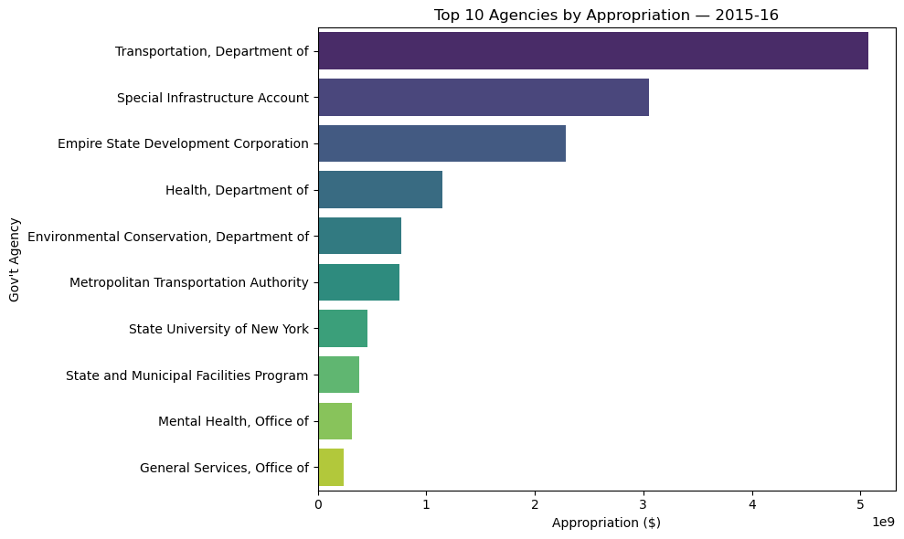

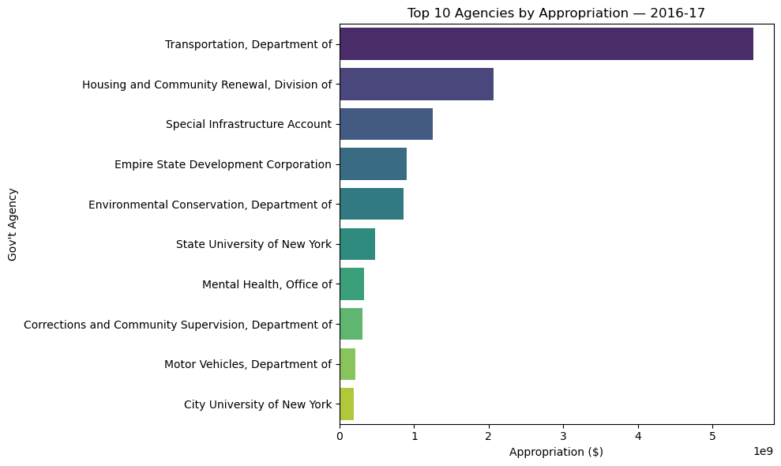

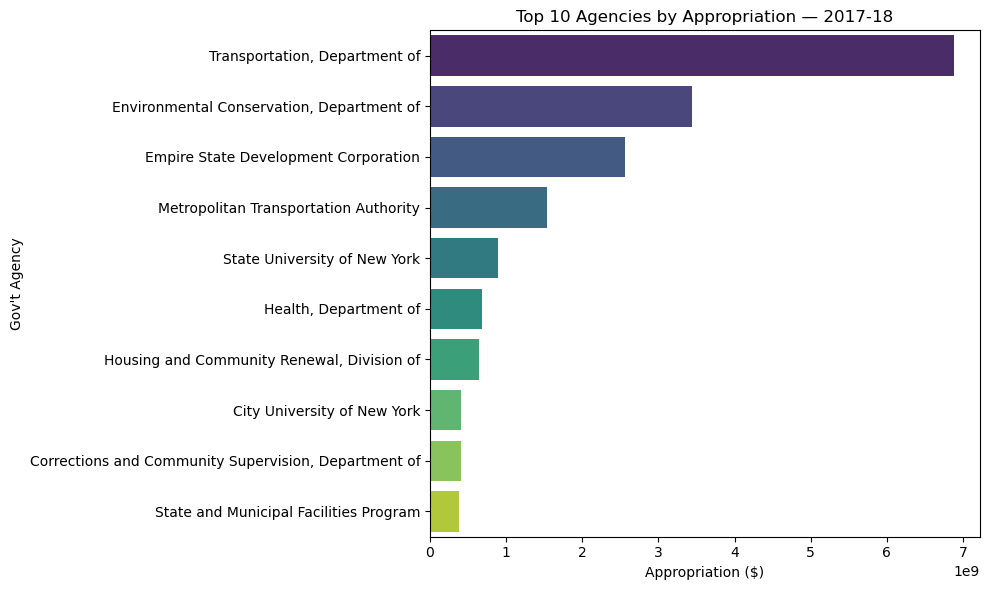

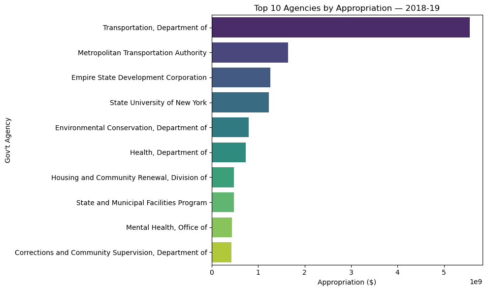

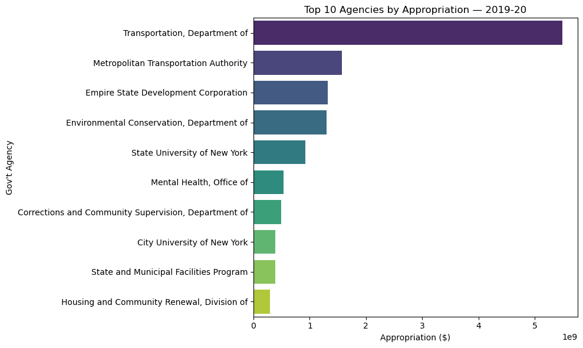

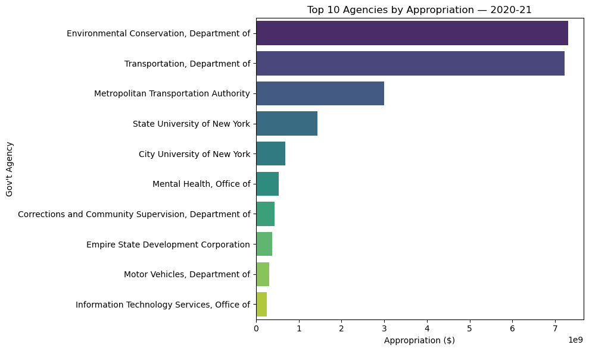

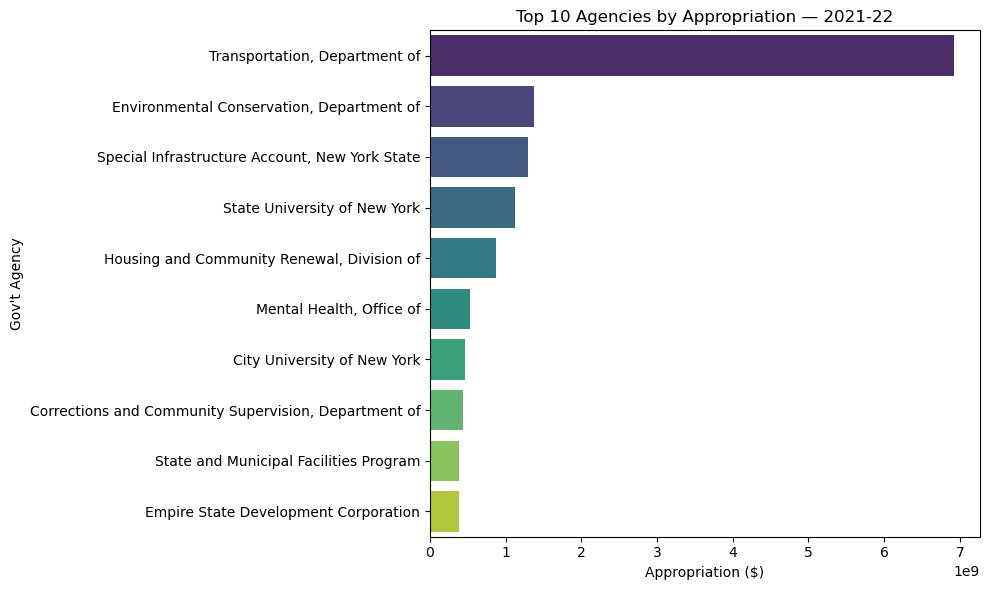

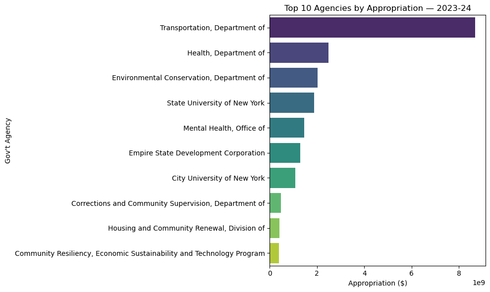

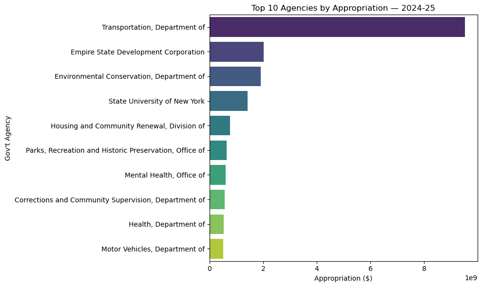

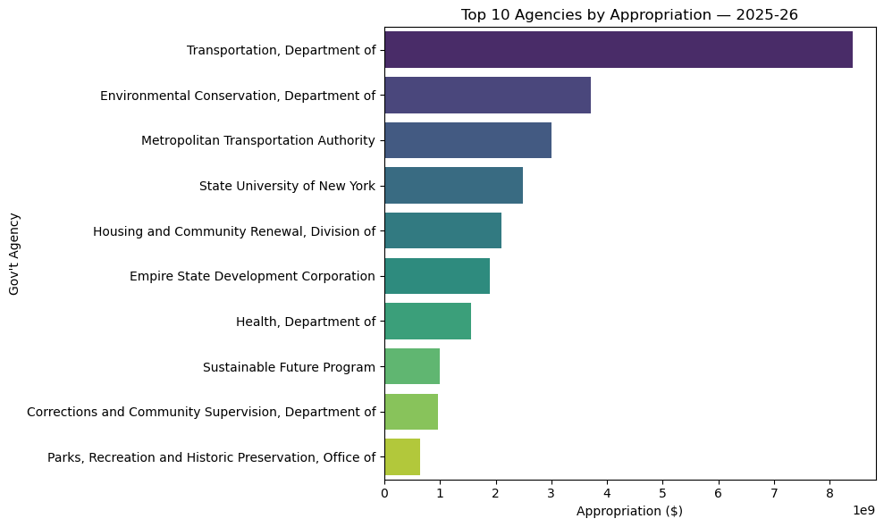

```python
import matplotlib.pyplot as plt
import seaborn as sns

top_n = 10

# Loop over fiscal periods
for period in sorted(df_times["fiscal_period"].unique()):
    df_period = df_times[df_times["fiscal_period"] == period]

    # Aggregate and get top N agencies
    df_rank = (
        df_period.groupby("agency_name")["appropriations"]
        .sum()
        .sort_values(ascending=False)
        .head(top_n)
        .reset_index()
    )

    plt.figure(figsize=(10,6))

    # Use hue for colors
    sns.barplot(
        x="appropriations",
        y="agency_name",
        data=df_rank,
        hue="agency_name",      # each bar gets its own color
        dodge=False,
        palette="viridis"
    )

    plt.title(f"Top {top_n} Agencies by Appropriation — {period}")
    plt.xlabel("Appropriation ($)")
    plt.ylabel("Gov't Agency")

    # Remove duplicate legend (since hue = y)
    plt.legend([],[], frameon=False)

    plt.tight_layout()
    plt.show()
```

Ranking scheme over time:

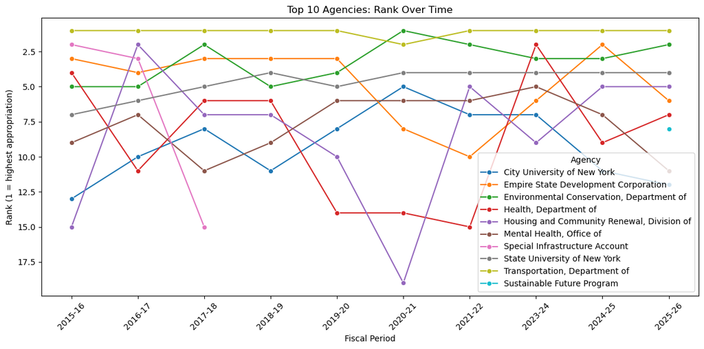

```python
top_n = 10  # number of sectors to track

# 1. Aggregate total appropriation by sector & fiscal_period
agg = df_times.groupby(["fiscal_period", "agency_name"])["appropriations"].sum().reset_index()

# 2. Compute ranks per year (1 = largest appropriation)
agg["rank"] = agg.groupby("fiscal_period")["appropriations"].rank(ascending=False, method="min")

# 3. Select top N sectors based on **average rank over all years**
avg_rank = agg.groupby("agency_name")["rank"].mean().sort_values().head(top_n)
top_sectors = avg_rank.index

agg_top = agg[agg["agency_name"].isin(top_sectors)]


# Plot cumulative rank over time
plt.figure(figsize=(12,6))
sns.lineplot(
    data=agg_top,
    x="fiscal_period",
    y="rank",
    hue="agency_name",
    marker="o",
    palette="tab10"
)

plt.gca().invert_yaxis()  # rank 1 on top
plt.title(f"Top {top_n} Agencies: Rank Over Time")
plt.ylabel("Rank (1 = highest appropriation)")
plt.xlabel("Fiscal Period")
plt.xticks(rotation=45)
plt.legend(title="Agency")
plt.tight_layout()
plt.show()
```

#### Dominance Measures

**Proportion of Total Budget (relative contribution)**

For each fiscal year, computing the sector’s appropriation as a fraction of total appropriations for that year:

$$\text{Share}_{sector,\,year}=\frac{\text{Appropriation}_{sector,\,year}}{\text{Total Appropriation}_{year}}$$

```python
# 1. Aggregate total appropriation per fiscal year & sector
agg = df_times.groupby(["fiscal_period", "agency_name"])["appropriations"].sum().reset_index()

# 2. Compute total per year
total_per_year = agg.groupby("fiscal_period")["appropriations"].sum().reset_index()
total_per_year = total_per_year.rename(columns={"appropriations": "total_year"})

# 3. Merge totals back
agg = agg.merge(total_per_year, on="fiscal_period")

# 4. Compute share %
agg["share"] = (agg["appropriations"] / agg["total_year"]) * 100

agg.head(50)
```

|  | fiscal_period | agency_name | appropriations | total_year | share |
| --- | --- | --- | --- | --- | --- |
| 0 | 2015-16 | Adirondack Park Agency | 0.000000e+00 | 1.572026e+10 | 0.000000 |
| 1 | 2015-16 | Agriculture and Markets, Department of | 5.500000e+06 | 1.572026e+10 | 0.034987 |
| 2 | 2015-16 | Alcoholism and Substance Abuse Services, Offic... | 9.500000e+06 | 1.572026e+10 | 0.060432 |
| 3 | 2015-16 | Children and Family Services, Office of | 1.476750e+08 | 1.572026e+10 | 0.939393 |
| 4 | 2015-16 | City University of New York | 1.609080e+08 | 1.572026e+10 | 1.023571 |
| 5 | 2015-16 | Community Enhancement Facilities Assistance | 0.000000e+00 | 1.572026e+10 | 0.000000 |
| 6 | 2015-16 | Corrections and Community Supervision, Departm... | 1.500000e+07 | 1.572026e+10 | 0.095418 |
| 7 | 2015-16 | Economic Development Capital | 0.000000e+00 | 1.572026e+10 | 0.000000 |
| 8 | 2015-16 | Economic Development Program, New York State | 0.000000e+00 | 1.572026e+10 | 0.000000 |
| 9 | 2015-16 | Education Department, State | 1.740000e+07 | 1.572026e+10 | 0.110685 |
| 10 | 2015-16 | Empire State Development Corporation | 2.289723e+09 | 1.572026e+10 | 14.565428 |
| 11 | 2015-16 | Energy Research and Development Authority, New... | 1.250000e+07 | 1.572026e+10 | 0.079515 |
| 12 | 2015-16 | Environmental Conservation, Department of | 7.719000e+08 | 1.572026e+10 | 4.910224 |
| 13 | 2015-16 | General Services, Office of | 2.420000e+08 | 1.572026e+10 | 1.539415 |
| 14 | 2015-16 | Health, Department of | 1.150600e+09 | 1.572026e+10 | 7.319218 |
| 15 | 2015-16 | High Technology and Development Program | 0.000000e+00 | 1.572026e+10 | 0.000000 |
| 16 | 2015-16 | Higher Education Facilities Capital Matching G... | 3.000000e+07 | 1.572026e+10 | 0.190837 |
| 17 | 2015-16 | Homeland Security and Emergency Services, Divi... | 1.500000e+07 | 1.572026e+10 | 0.095418 |
| 18 | 2015-16 | Housing and Community Renewal, Division of | 9.120000e+07 | 1.572026e+10 | 0.580143 |
| 19 | 2015-16 | Hudson River Park Trust | 0.000000e+00 | 1.572026e+10 | 0.000000 |
| 20 | 2015-16 | Information Technology Services, Office of | 8.570000e+07 | 1.572026e+10 | 0.545156 |
| 21 | 2015-16 | Jacob Javits Convention Center | 0.000000e+00 | 1.572026e+10 | 0.000000 |
| 22 | 2015-16 | Judiciary | 0.000000e+00 | 1.572026e+10 | 0.000000 |
| 23 | 2015-16 | Law, Department of | 1.000000e+06 | 1.572026e+10 | 0.006361 |
| 24 | 2015-16 | Mental Health, Office of | 3.124720e+08 | 1.572026e+10 | 1.987703 |
| 25 | 2015-16 | Metropolitan Transportation Authority | 7.500000e+08 | 1.572026e+10 | 4.770914 |
| 26 | 2015-16 | Military and Naval Affairs, Division of | 3.920000e+07 | 1.572026e+10 | 0.249360 |
| 27 | 2015-16 | Motor Vehicles, Department of | 1.992550e+08 | 1.572026e+10 | 1.267505 |
| 28 | 2015-16 | Nonprofit Infrastructure Capital Investment Pr... | 5.000000e+07 | 1.572026e+10 | 0.318061 |
| 29 | 2015-16 | Olympic Regional Development Authority | 7.500000e+06 | 1.572026e+10 | 0.047709 |
| 30 | 2015-16 | Parks, Recreation and Historic Preservation, O... | 1.737000e+08 | 1.572026e+10 | 1.104944 |
| 31 | 2015-16 | People with Developmental Disabilities, Office... | 1.800000e+07 | 1.572026e+10 | 0.114502 |
| 32 | 2015-16 | Public Security and Emergency Response | 0.000000e+00 | 1.572026e+10 | 0.000000 |
| 33 | 2015-16 | Regional Economic Development Program | 0.000000e+00 | 1.572026e+10 | 0.000000 |
| 34 | 2015-16 | Special Infrastructure Account | 3.050000e+09 | 1.572026e+10 | 19.401716 |
| 35 | 2015-16 | State Equipment Finance Program | 0.000000e+00 | 1.572026e+10 | 0.000000 |
| 36 | 2015-16 | State Police, Division of | 3.150000e+07 | 1.572026e+10 | 0.200378 |
| 37 | 2015-16 | State University of New York | 4.624270e+08 | 1.572026e+10 | 2.941599 |
| 38 | 2015-16 | State and Municipal Facilities Program | 3.850000e+08 | 1.572026e+10 | 2.449069 |
| 39 | 2015-16 | State, Department of | 0.000000e+00 | 1.572026e+10 | 0.000000 |
| 40 | 2015-16 | Strategic Investment Program | 0.000000e+00 | 1.572026e+10 | 0.000000 |
| 41 | 2015-16 | Temporary and Disability Assistance, Office of | 6.350000e+07 | 1.572026e+10 | 0.403937 |
| 42 | 2015-16 | Thruway Authority, New York State | 0.000000e+00 | 1.572026e+10 | 0.000000 |
| 43 | 2015-16 | Transportation, Department of | 5.072099e+09 | 1.572026e+10 | 32.264729 |
| 44 | 2015-16 | Workers' Compensation Board | 6.000000e+07 | 1.572026e+10 | 0.381673 |
| 45 | 2015-16 | World Trade Center | 0.000000e+00 | 1.572026e+10 | 0.000000 |
| 46 | 2016-17 | Adirondack Park Agency | 0.000000e+00 | 1.307378e+10 | 0.000000 |
| 47 | 2016-17 | Agriculture and Markets, Department of | 5.500000e+06 | 1.307378e+10 | 0.042069 |
| 48 | 2016-17 | Alcoholism and Substance Abuse Services, Offic... | 2.300000e+07 | 1.307378e+10 | 0.175925 |
| 49 | 2016-17 | Audit and Control, Department of | 6.000000e+06 | 1.307378e+10 | 0.045893 |

Plotting with order:

[figure not shown]

```python
# Filter to sectors with greater than 5% share
agg_plot = agg[agg["share"] >= 5]

# Sort agencies by share within each year
agg_plot = agg_plot.sort_values(["fiscal_period", "share"], ascending=[True, False])

# Pivot for stacked bar plot
agg_pivot = agg_plot.pivot(index="fiscal_period", columns="agency_name", values="share").fillna(0)

# REMOVED: The problematic line that replaced numeric data with column indices
# agg_pivot = agg_pivot.apply(lambda x: x.sort_values(ascending=False).index, axis=1)

# Optional: Sort columns by their average values (alternative approach to reordering)
agg_pivot = agg_pivot[agg_pivot.mean().sort_values(ascending=False).index]

# Plot
fig, ax = plt.subplots(figsize=(12, 6))
agg_pivot.plot(kind="bar", stacked=True, ax=ax, colormap="tab20")

# Customize axes
ax.set_ylabel("Share of Total Appropriation (%)")
ax.set_xlabel("Fiscal Year")
ax.set_xticklabels(ax.get_xticklabels(), rotation=90)  # vertical x labels
ax.set_title("Major Agency Budget Shares per Fiscal Year (≥10%)")
ax.legend(title="Agency", bbox_to_anchor=(1.05, 1), loc='upper left')

plt.tight_layout()
plt.show()
```

1. **Understand the "Whole"**

In a stacked bar chart, the total height of the bar represents the cumulative share of the agencies listed.

Analysis Tip: If the total height of a bar increases (like in 2016-17 or 2020-21), it means the "Major Agencies" took up a larger portion of the overall budget that year, leaving less for smaller departments.

2. **Identify the "Anchor" (The Base Layer)**

The Department of Transportation (DOT) is the blue base layer. Because it starts at zero, it is the easiest to read.

Observation: In 2025-26, the DOT share (blue) noticeably dips compared to the previous year, while other agencies like the MTA (red) and Health (grey) expand.

3. **Measure the "Thickness" (Relative Share)**

For any color above the blue base, you cannot look at the numbers on the Y-axis directly. You must subtract the bottom value from the top value of that specific color segment.

Example (2020-21): The orange segment (Environmental Conservation) starts at roughly 31 and ends at roughly 62. Its share is approximately $62 - 31 = 31\%$. Visual Cue: Look for the volume of the color block rather than its position on the grid.

4. **Spot the "Interlopers" (Inconsistent Funding)**

Some agencies only appear in specific years. This usually indicates one-time projects or emergency funding.

5. **Look for "Trade-offs"**

Compare the segments across two adjacent years.

In 2020-21, the orange bar (Environmental Conservation) is massive. Notice that the green bar (Empire State Development) is completely absent that year. This suggests a massive shift in priority or a reclassification of funds during that period.

[output not shown]

### Economic Inequality in Public Spending (policy based)

Economic inequality generally refers to the "gap" between different groups in an economy. When applying concentration metrics one is essentially looking at a specific arrangement of economic inequality: the distribution of resources across competing entities. In the context of this specific dataset, inequality manifests as **Budgetary Priority** involving gov't agencies.

Appropriations distribution at the agency level is a relevantion of gov't policy since most or all agencies fall under the executive branch. Results from cocentration metrics and observation of prior data visualisations provide an overall storytelling of gov't policy.

**Gini Index**

The Gini index is one of the most used inequality index, often used to measure income inequality (Karam and Ryerson, 2023).

The provided expression form simplifies the relationship between the cumulative share of income and the cumulative share of the population (the Lorenz Curve).

$$G = \frac{\sum_{i=1}^{n} (2i-n-1)x_i}{n \sum_{i=1}^{n} x_i}$$

The variables in the formula are defined as follows:

$x_i$: The value of the $i$-th observation (e.g., the income of the $i$-th agency or programme).

$n$: The total number of observations/programmes in the sample.

$i$: The rank of the observation/programme, ranging from 1 to $n$.

$\sum_{i=1}^{n} x_i$: The total sum of all values in the dataset.

$(2i-n-1)$: A weighting factor that assigns more weight to observations/programmes at the top of the distribution.

**Key Considerations:**

Sorting: If the data is not sorted, the formula will not yield the correct Gini coefficient.

Relative Measure: It is a ratio and therefore independent of the absolute scale of the values (e.g., it remains the same whether income is measured in dollars or cents).

**Intepretation for the Budget Data**

1. $x_i$ = appropriations per program/agency
2. grouped by FiscalYear:

$$G_{year} = \frac{\sum_{i=1}^{n} (2i-n-1)x_i}{n \sum_{i=1}^{n} x_i}$$

Interpretation:

0 → perfectly equal spending across programs

1 → all spending concentrated in one program

Gini Coefficient (Spending Concentration):

```python
import numpy as np

def gini(x):
    x = np.sort(x)
    n = len(x)
    return (2 * np.arange(1, n+1) - n - 1).dot(x) / (n * x.sum())
```

Apply Gini per fiscal period for agencies:

```python
# Aggregate appropriations per agency or program for each year
agg_year = df_times.groupby(["fiscal_period", "agency_name"])["appropriations"].sum().reset_index()

# Compute Gini per fiscal period
gini_by_year = agg_year.groupby("fiscal_period")["appropriations"].apply(lambda x: gini(x.values))

print(gini_by_year)
```

```
fiscal_period
2015-16    0.851492
2016-17    0.870246
2017-18    0.833937
2018-19    0.817813
2019-20    0.818145
2020-21    0.872493
2021-22    0.822807
2023-24    0.844174
2024-25    0.842106
2025-26    0.831741
Name: appropriations, dtype: float64
```

Observed is spending concentrated towards a few agencies.

**The Theil Index**

The Theil Index is a statistic used to measure economic inequality and other forms of segregation (Bellù and Liberati, 2006). Unlike the more famous Gini coefficient, the Theil Index is derived from information theory (specifically Shannon's entropy) and is prized by researchers for its ability to be perfectly decomposed into "within-group" and "between-group" components.

In this context—where each row represents a unique, independent apprpriation w.r.t. gov't agency and programmes—the Theil index can be applied to measure the inequality of apprporiations across a dataset.

$$T = \frac{1}{n} \sum_{i=1}^{n} \frac{x_i}{\bar{x}} \ln\left(\frac{x_i}{\bar{x}}\right)$$

where:

$n$ is the number of apprpriations,

$x_i$ is appropriation (or value) towards the $i$-th gov't agency or programme.

$\bar{x}$ is mean appropriation for the entire agencies/programmes spectrum, expressed as

$$\bar{x} = \frac{1}{n} \sum x_i$$

**Interpretation:**

1. 0 $\longrightarrow$ equality
2. larger values $\longrightarrow$ increasing concentration

```python
def theil(x):
    x = x[x > 0]
    mean = x.mean()
    return np.mean((x/mean) * np.log(x/mean))

theil_year = df_times.groupby("fiscal_period")["appropriations"].apply(theil)

theil_year
```

```
fiscal_period
2015-16    1.539977
2016-17    1.578081
2017-18    1.643263
2018-19    1.442980
2019-20    1.454816
2020-21    1.844498
2021-22    1.538675
2023-24    1.537588
2024-25    1.532535
2025-26    1.483080
Name: appropriations, dtype: float64
```

## Data Analysis (programme based)

Following policy based observation involving appropriations, to now observe the actual use of the appropriations. Hence more granularity.

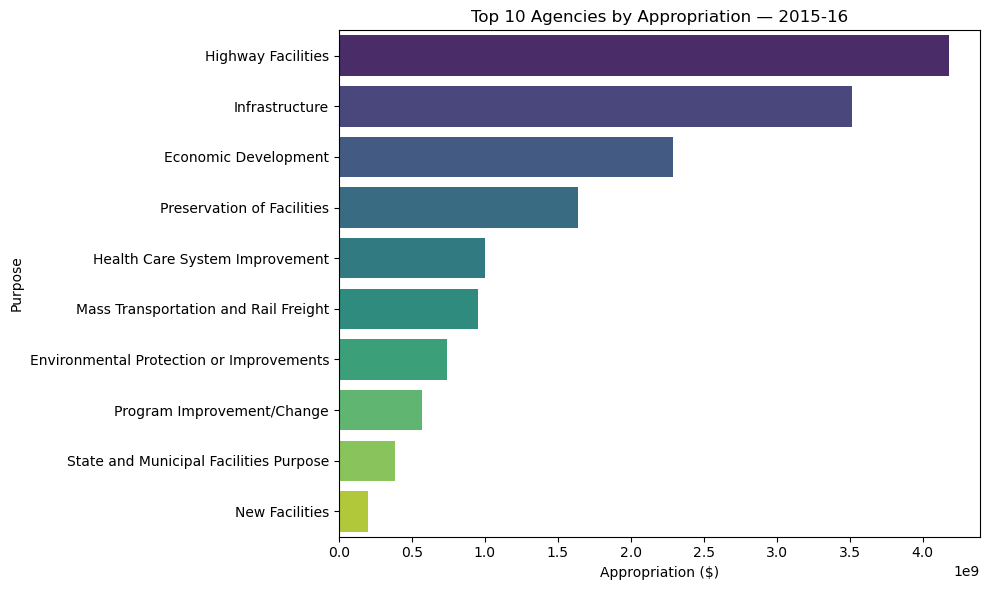

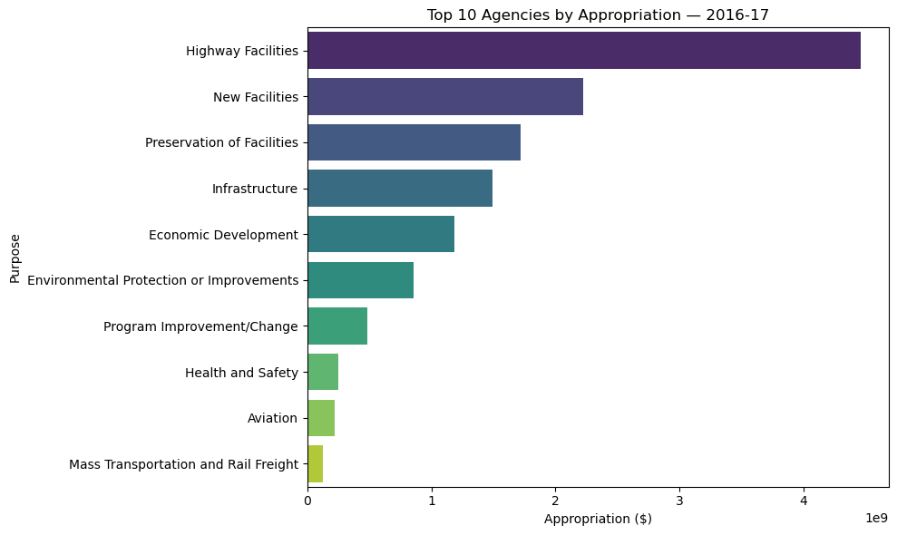

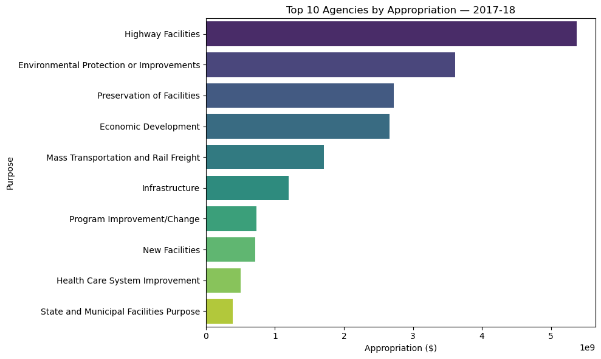

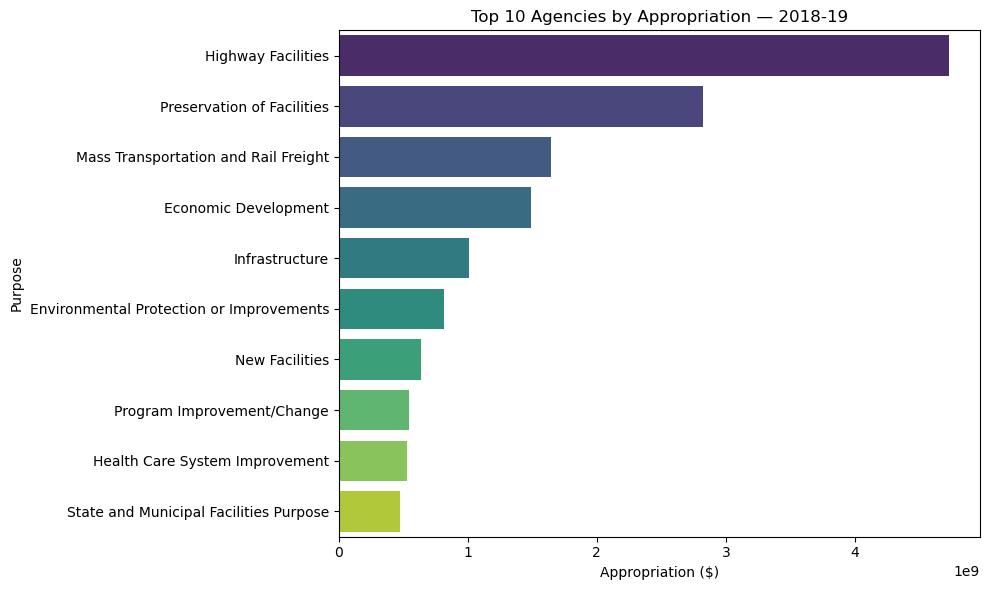

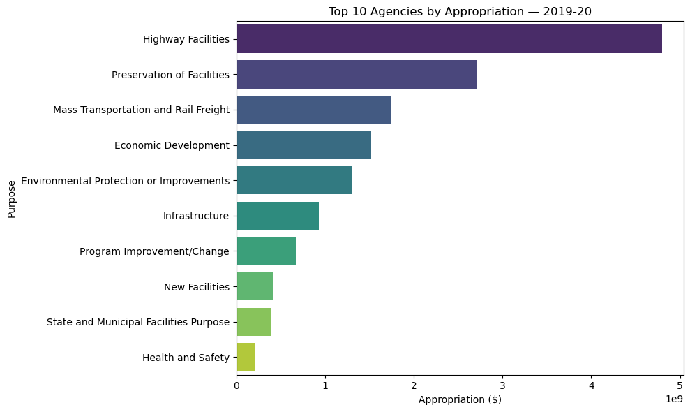

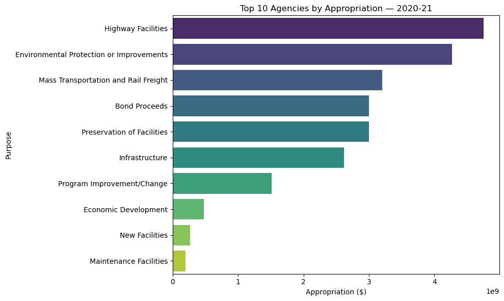

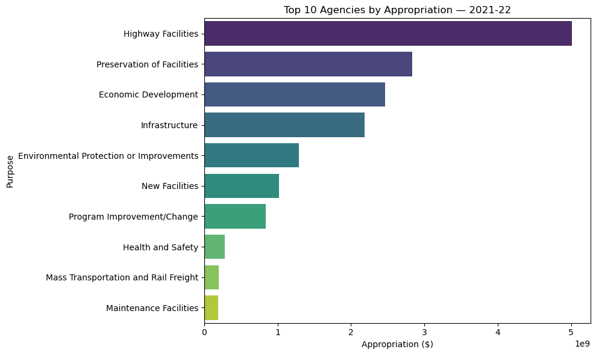

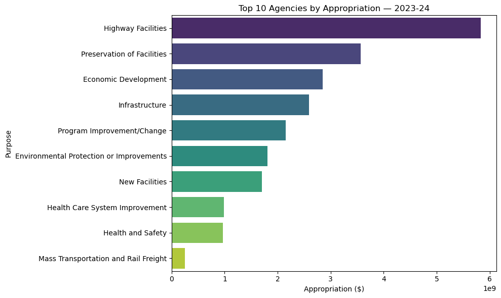

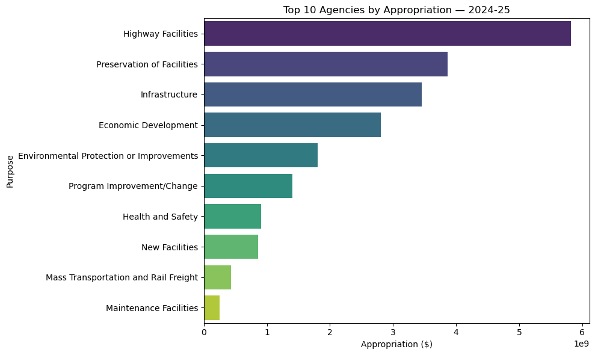

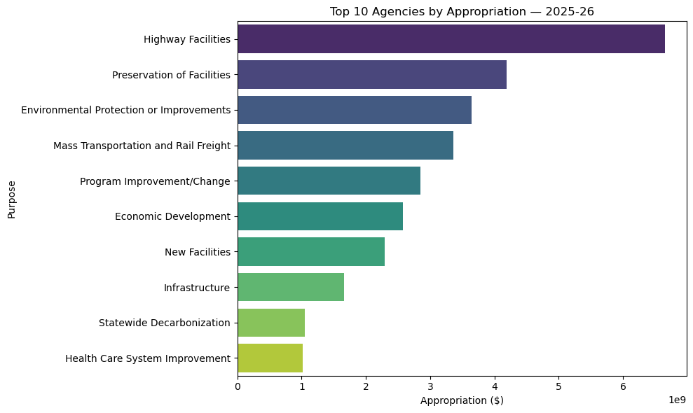

```python
import matplotlib.pyplot as plt
import seaborn as sns

top_n = 10

# Loop over fiscal periods
for period in sorted(df_times["fiscal_period"].unique()):
    df_period = df_times[df_times["fiscal_period"] == period]

    # Aggregate and get top N intensions
    df_rank = (
        df_period.groupby("state_purpose")["appropriations"]
        .sum()
        .sort_values(ascending=False)
        .head(top_n)
        .reset_index()
    )

    plt.figure(figsize=(10,6))

    # Use hue for colors
    sns.barplot(
        x="appropriations",
        y="state_purpose",
        data=df_rank,
        hue="state_purpose",      # each bar gets its own color
        dodge=False,
        palette="viridis"
    )

    plt.title(f"Top {top_n} Agencies by Appropriation — {period}")
    plt.xlabel("Appropriation ($)")
    plt.ylabel("Purpose")

    # Remove duplicate legend (since hue = y)
    plt.legend([],[], frameon=False)

    plt.tight_layout()
    plt.show()
```